# ARM: Chapter 11

### Question 1

*The file apt.dat in the folder rodents contains data on rodent infestation in a sample of New York City apartments (see codebook rodents.doc). The file dist.dat contains data on the 55 “community districts” (neighborhoods) in the city.*

```r
apt <- read.table(str_c(arm_url, 'rodents/apt.dat'))
dis <- read.table(str_c(arm_url, 'rodents/dist.dat'))
```

#### (a)

*Write the notation for a varying-intercept multilevel logistic regression (with community districts as the groups) for the probability of rodent infestation using the individual-level predictors but no group-level predictors.*

$$P(y_{ij} = 1) = \text{logit}^{-1} \left( \beta_0 + \beta_1 \times \text{defects}_i + \beta_2 \times \text{race}_i + \beta_3 \times \text{floor}_i + \beta_4 \times \text{bldg}_i + \alpha_j \right)$$

#### (b)

*Expand the model in (a) by including the variables in dist.dat as group-level predictors.*

$$\begin{align}
P(y_{i} = 1) &= \text{logit}^{-1} \left( \beta_0 + \beta_1 \times \text{defects}_i + \beta_2 \times \text{race}_i + \beta_3 \times \text{floor}_i + \beta_4 \times \text{bldg}_i + \alpha_{j[i]} \right) \\
\alpha_{j[i]} &\sim N \left( \gamma_0 + \gamma_1 \times \text{defects}_j + \gamma_2 \times \text{poor}_j, \sigma_{\alpha} ^ 2 \right)
\end{align}$$

### Question 2

Skip

### Question 3

*The folder olympics has seven judges’ ratings of seven figure skaters (on two criteria: “technical merit” and “artistic impression”) from the 1932 Winter Olympics.*

```r
win32 <- read_table2(str_c(arm_url, 'olympics/olympics1932.txt'), skip = 20)
```

#### (a)

*Construct a 7 × 7 × 2 array of the data (ordered by skater, judge, and judging criterion).*

```r
pro32 <- cbind(1:7, win32[seq(1, 14, by = 2), 3:9])
per32 <- cbind(1:7, win32[seq(2, 14, by = 2), 2:8])
names(pro32) <- c('pair', str_c('judge_', 1:7))
names(per32) <- c('pair', str_c('judge_', 1:7))
```

#### (b)

*Reformulate the data as a 98×4 array (similar to the top table in Figure 11.7), where the first two columns are the technical merit and artistic impression scores, the third column is a skater ID, and the fourth column is a judge ID.*

```r
dat <- left_join(
  gather(pro32, judge, score, -pair),
  gather(per32, judge, score, -pair),
  by = c('pair', 'judge')
)
dat %<>% mutate_at(vars(score.x, score.y), as.numeric)
dat$judge %<>% str_replace_all('judge_', '') %>% as.numeric()
names(dat)[3:4] <- c('tech', 'perf')
dat <- dat[c(3:4, 1:2)]
```

#### (c)

*Add another column to this matrix representing an indicator variable that equals 1 if the skater and judge are from the same country, or 0 otherwise.*

```r
dat %<>%
  mutate(
    same = 0,
    same = if_else(pair == 1 & judge == 5, 1, same),
    same = if_else(pair == 2 & judge == 7, 1, same),
    same = if_else(pair == 3 & judge == 1, 1, same),
    same = if_else(pair == 4 & judge == 1, 1, same),
    same = if_else(pair == 7 & judge == 7, 1, same)
  )
```

### Question 4

*The folder cd4 has CD4 percentages for a set of young children with HIV who were measured several times over a period of two years. The dataset also includes the ages of the children at each measurement.*

#### (a)

*Graph the outcome (the CD4 percentage, on the square root scale) for each child as a function of time.*

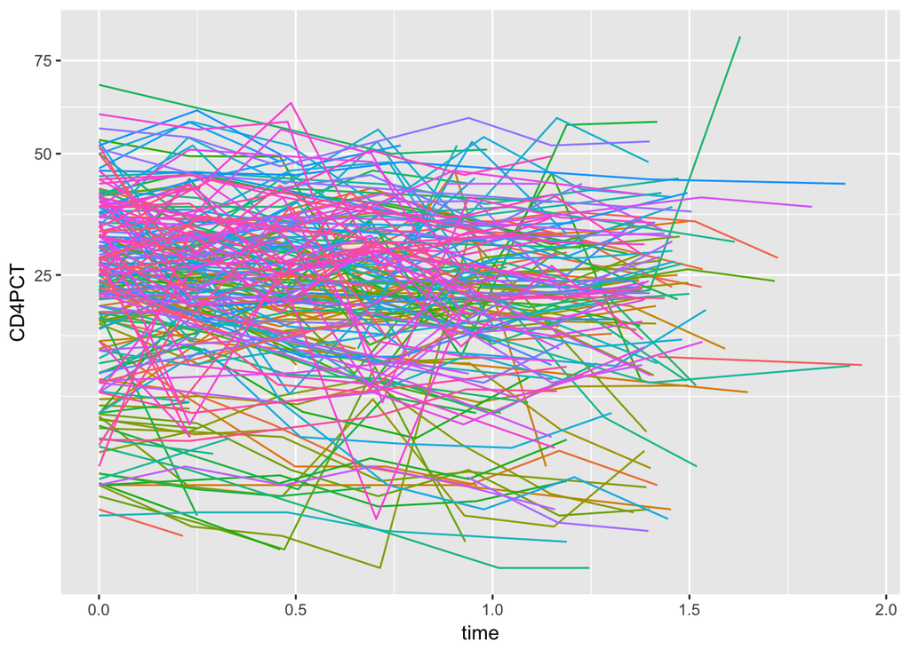

```r
cd4 <- read_csv(str_c(arm_url, 'cd4/allvar.csv'))
cd4 %<>% mutate(time = visage - baseage)

p <- ggplot(cd4) +
  geom_line(aes(time, CD4PCT, colour = factor(newpid))) +
  scale_y_sqrt() +
  guides(colour = F)
p
```

#### (b)

*Each child’s data has a time course that can be summarized by a linear fit. Estimate these lines and plot them for all the children.*

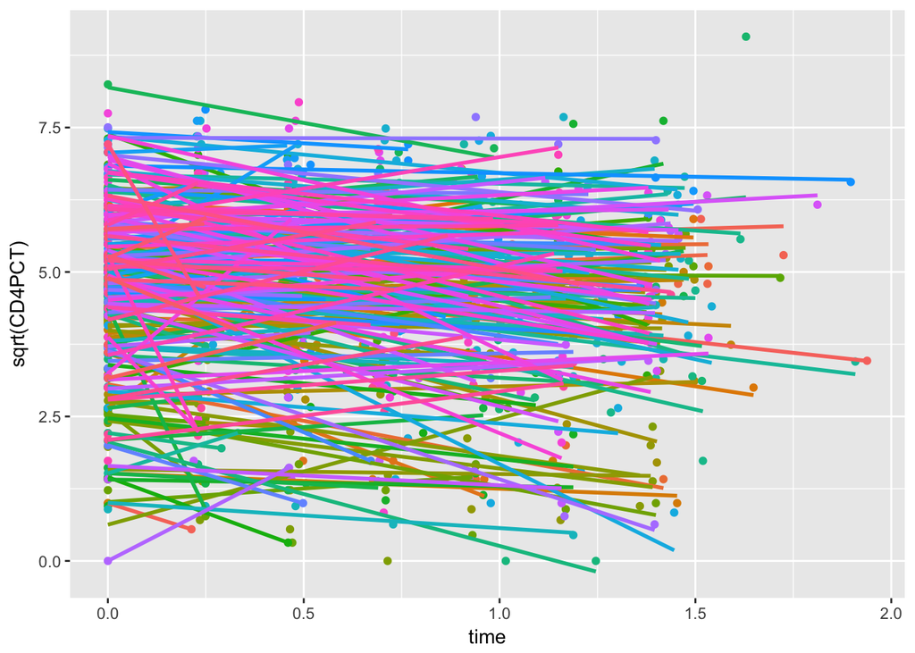

```r
p <- ggplot(cd4) +
  geom_point(aes(time, sqrt(CD4PCT), colour = factor(newpid))) +
  geom_smooth(
    aes(time, sqrt(CD4PCT), colour = factor(newpid)),
    method = 'lm', se = F
    ) +
  guides(colour = F)
p
```

#### (c)

*Set up a model for the children’s slopes and intercepts as a function of the treatment and age at baseline. Estimate this model using the two-step procedure–first estimate the intercept and slope separately for each child, then fit the between-child models using the point estimates from the first step.*